# Practical machine learning project from Coursera

Dauhee

22 August 2017

## Project Goal

The goal of this project is to predict the manner in which a number of test subjects performed a dumbbell curl exercise. There is a “classe” variable that indicates the particular manner executed:

- exactly according to the specification (Class A)
- throwing the elbows to the front (Class B)
- lifting the dumbbell only halfway (Class C)
- lowering the dumbbell only halfway (Class D)
- throwing the hips to the front (Class E)

Cross validation must be used and explanations for choices made in the assignment. There are also 20 test dataset records to have the “classe” variable predicted. Comments have been put in-place with code to clarify choices and reasons

```r
suppressMessages(suppressWarnings(traindf <- read_csv("pml-training.csv", na=c("#DIV/0!", "NA", ""))))
suppressMessages(suppressWarnings(testdf <- read_csv("pml-testing.csv", na=c("#DIV/0!", "NA", ""))))

#get rid of index and also timestamp as time is static for each individual. Are presuming time of day has no
#impact on prediction. Removal of near zero values later would probably get rid of static timestamp also
traindf <- subset(traindf, select = -c(X1, cvtd_timestamp))
testdf <- subset(testdf, select = -c(X1, cvtd_timestamp))
```

```r
#get columns that have nulls
lst<- apply(traindf, 2, function(x) sum(is.na(x)) )
#as can be seen, some columns have a very low amount of missing values. Include these in the model but impute
lst[lst>0]
```

```
##       kurtosis_roll_belt      kurtosis_picth_belt        kurtosis_yaw_belt
##                    19226                    19248                    19622
##       skewness_roll_belt     skewness_roll_belt.1        skewness_yaw_belt
##                    19225                    19248                    19622
##            max_roll_belt           max_picth_belt             max_yaw_belt
##                    19216                    19216                    19226
##            min_roll_belt           min_pitch_belt             min_yaw_belt
##                    19216                    19216                    19226
##      amplitude_roll_belt     amplitude_pitch_belt       amplitude_yaw_belt
##                    19216                    19216                    19226
##     var_total_accel_belt            avg_roll_belt         stddev_roll_belt
##                    19216                    19216                    19216
##            var_roll_belt           avg_pitch_belt        stddev_pitch_belt
##                    19216                    19216                    19216
##           var_pitch_belt             avg_yaw_belt          stddev_yaw_belt
##                    19216                    19216                    19216
##             var_yaw_belt            var_accel_arm             avg_roll_arm
##                    19216                    19216                    19216
##          stddev_roll_arm             var_roll_arm            avg_pitch_arm
##                    19216                    19216                    19216
##         stddev_pitch_arm            var_pitch_arm              avg_yaw_arm
##                    19216                    19216                    19216
##           stddev_yaw_arm              var_yaw_arm        kurtosis_roll_arm
##                    19216                    19216                    19294
##       kurtosis_picth_arm         kurtosis_yaw_arm        skewness_roll_arm
##                    19296                    19227                    19293
##       skewness_pitch_arm         skewness_yaw_arm             max_roll_arm
##                    19296                    19227                    19216
##            max_picth_arm              max_yaw_arm             min_roll_arm
##                    19216                    19216                    19216
##            min_pitch_arm              min_yaw_arm       amplitude_roll_arm
##                    19216                    19216                    19216
##      amplitude_pitch_arm        amplitude_yaw_arm   kurtosis_roll_dumbbell
##                    19216                    19216                    19221
##  kurtosis_picth_dumbbell    kurtosis_yaw_dumbbell   skewness_roll_dumbbell
##                    19218                    19622                    19220
##  skewness_pitch_dumbbell    skewness_yaw_dumbbell        max_roll_dumbbell
##                    19217                    19622                    19216
##       max_picth_dumbbell         max_yaw_dumbbell        min_roll_dumbbell
##                    19216                    19221                    19216
```

[output cut: 15 more lines]

```
##                    19622                    19216                    19216
##          max_yaw_forearm         min_roll_forearm        min_pitch_forearm
##                    19300                    19216                    19216
##          min_yaw_forearm   amplitude_roll_forearm  amplitude_pitch_forearm
##                    19300                    19216                    19216
##    amplitude_yaw_forearm        var_accel_forearm         avg_roll_forearm
##                    19300                    19216                    19216
##      stddev_roll_forearm         var_roll_forearm        avg_pitch_forearm
##                    19216                    19216                    19216
##     stddev_pitch_forearm        var_pitch_forearm          avg_yaw_forearm
##                    19216                    19216                    19216
##       stddev_yaw_forearm          var_yaw_forearm         magnet_forearm_y
##                    19216                    19216                        1
##         magnet_forearm_z
##                        1
```

```r
pct1 <- round((dim(traindf)[1]) / 100)

#delete colums that have more than 1% missing
traindf <- traindf[, !names(traindf) %in% names(lst[lst>pct1])]
testdf <- testdf[, !names(testdf) %in% names(lst[lst>pct1])]

#magnet sensor appears to have failed for just 1 row on the train data, none on test
dim(traindf[rowSums(is.na(traindf)) > 0,])[1]
```

```
## [1] 1
```

```r
dim(testdf[rowSums(is.na(testdf)) > 0,])[1]
```

```
## [1] 0
```

## Inital investigation

```r
#seems like good mix of each classe for analysis
table(traindf$classe)
```

```
##
##    A    B    C    D    E
## 5580 3797 3422 3216 3607
```

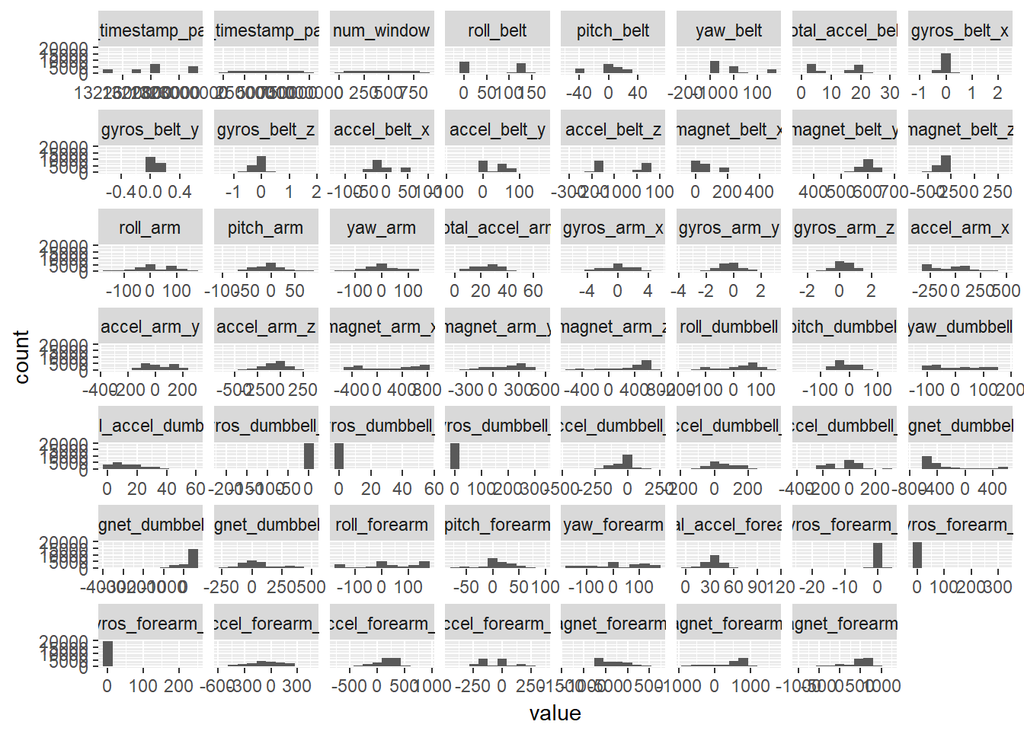

```r
#data appears non-linear for many of the variables
ggplot(data = melt(traindf), mapping = aes(x = value)) +
  geom_histogram(bins = 10) + facet_wrap(~variable, scales = 'free_x')
```

```r
#factorize classe as it is categorical
traindf$classe = factor(traindf$classe)

#remove variables that do not contribute to building model of prediction - i.e. static values
nearZ <- nearZeroVar(traindf)
traindf <- traindf[-nearZ, ]
```

## Model selection

So there is a non-linear distribution of data for many of the variables. Our outcome is a classification type. This would indicate that random forest, generalized boosted regression model or linear discriminant analysis could be contenders. Because of random forest being deemed the heaveyweight of prediction accuracy, we will try that first. Then possibly doing a combined prediction to see if can get better accuracy.

```r
#doing the following when testing impute fails due to standard deviation calculation not possible
pPros <- preProcess(traindf, method="knnImpute", na.remove=FALSE)
#now using a different method of computing, this time the mean, in order to salvage the 1 record
trainDFImp <- mice(traindf, m=5, maxit=50, meth='mean', seed=500, printFlag = FALSE)
trainDFImp<-complete(trainDFImp,1)

#we have our full train dataset. Because of cross validation, will be computationally intensive so need to multi-thread
cluster <- makeCluster(detectCores() - 1) # convention to leave 1 core for OS
registerDoParallel(cluster)

#begin the creation of the model using random forest
mod1 <- train(classe ~ ., data=trainDFImp, trControl = trainControl(method="cv", number = 5, allowParallel = TRUE), method="rf")
stopCluster(cluster)
registerDoSEQ() #go back to single thread mode in R


pred1 <- predict(mod1, trainDFImp)
conf_mat <- confusionMatrix(pred1, trainDFImp$classe)
conf_mat$table
```

```
##           Reference
## Prediction    A    B    C    D    E
##          A 5579    0    0    0    0
##          B    0 3797    0    0    0
##          C    0    0 3422    0    0
##          D    0    0    0 3216    0
##          E    0    0    0    0 3607
```

```r
conf_mat$overall[[1]] * 100
```

```
## [1] 100
```

## High accuracy of model

Wow. We have a model accuracy prediction of 100% on our in-sample data. Looking at this, there is no need to continue tweaking with other methods or using combined models.

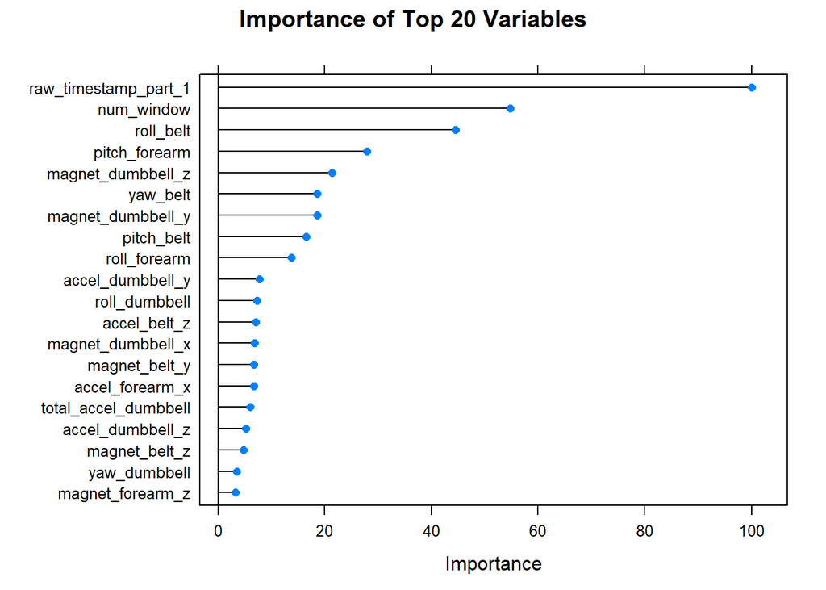

```r
varImpObj <- varImp(mod1)
plot(varImpObj, main = "Importance of Top 20 Variables", top = 20)
```

```r
#Finally, we predict on the test dataset
pred2 <- predict(mod1, testdf)
pred2
```

```
##  [1] B A B A A E D B A A B C B A E E A B B B
## Levels: A B C D E
```

## Summary

After completing the 20 sample quiz, it appears the model is 100% correct on out of sample test. It is interesting to see also the breakdown of the higher importance predictors as indicated in the plot. The cross validation using random forest turned out to be an excellent model for this data. No adjustments were required. This is always a good approach of less “tampering” with the model so that there are generally less out of sample errors encountered.